# تمرین سری سوم: از لالیگا تا لیگ برتر

#### ۱۰. سه آماره به همراه نمودار فردوسی پسند استخراج کنید.

##### پاسخ:

آماره ی اول، رتبه بندی بر اساس امتیاز تیم ها، در کل تاریخ لالیگا بدون محدود بودن به یک فصل خاص است:

```r
tmp = maketable_all(spain)
tmp %>%
  hchart(type="column", hcaes(x=team, y=Pts)) %>%
  hc_yAxis(title = list(text = "Points")) %>%
  hc_add_theme(hc_theme_elementary())
```

[interactive chart not shown]

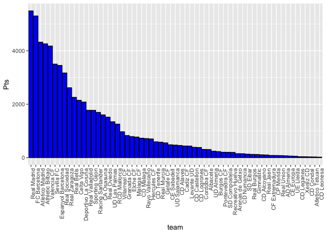

```r
tmp$team <- factor(tmp$team, levels=tmp$team[1:dim(tmp)[1]])
plot=ggplot(data=tmp, aes(x=team, y=Pts))
plot + geom_bar(stat = "identity", fill="blue", color="black")+
  theme(axis.text.x=element_text(angle=90, hjust=1))
```

آماره ی دوم، تحول اقتدار دو تیم برتر لالیگا، در طی زمان است. اگر میانگین تفاضل گل در هر سال را اقتدار تیم در آن سال در نظر بگیریم، تحول اقتدار رئال و بارسا در طی زمان به این صورت است:

```r
pl%>%
  group_by(Team, Season) %>%
  filter(Team=="FC Barcelona" || Team=="Real Madrid") %>%
  summarise(GD = mean(GD)) -> data

  hchart(data, type="line", hcaes(x=Season, y=GD, group=Team)) %>%
  hc_add_theme(hc_theme_elementary())
```

[interactive chart not shown]

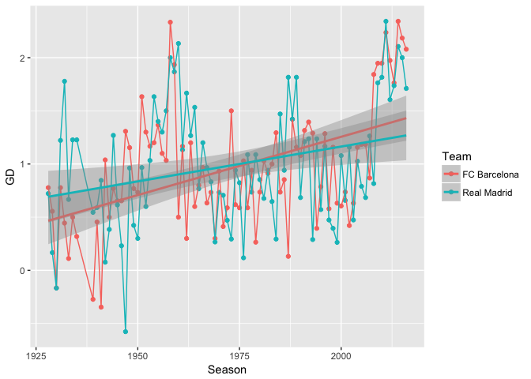

```r
  ggplot(data, aes(x=Season, y=GD, group=Team, color=Team)) +
    geom_point()+
    geom_line()+
    geom_smooth(method = "lm")
```

و در نهایت، آماره ی سوم میانگین تعداد گل در بازی ها در طی زمان است:

```r
  laliga %>%
    mutate(goals = hgoal+vgoal) %>%
    group_by(Season) %>%
    summarise(goals=mean(goals)) -> tmp
  hchart(tmp, type = "spline", hcaes(x=Season, y=goals))
```

[interactive chart not shown]

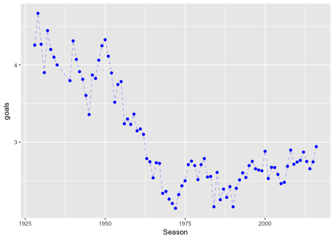

```r
  ggplot(tmp, aes(x=Season, y=goals)) +
  geom_point(color="blue") +
  geom_line(color="blue", linetype="dashed", alpha=0.3)
```

همانطور که از نمودار مشخص است، به طور میانگین بازی ها در طی زمان کم گل تر شده است